# Risk Factor Analysis

## Outcome Variable

**Outcome Variable:** ever_swasted

## Predictor Variables

**Intervention Variable:** gagebrth

**Adjustment Set:**

- arm
- sex
- W_mage
- meducyrs
- feducyrs
- hhwealth_quart
- single
- brthmon
- W_parity
- delta_W_mage
- delta_meducyrs
- delta_feducyrs
- delta_hhwealth_quart
- delta_single
- delta_brthmon
- delta_W_parity

## Stratifying Variables

The analysis was stratified on these variable(s):

- agecat
- studyid
- country

## Data Summary

| agecat | studyid | country | gagebrth | ever_swasted | n_cell | n |
| --- | --- | --- | --- | --- | --- | --- |
| 0-24 months (no birth wast) | ki1000108-CMC-V-BCS-2002 | INDIA | Full or late term | 0 | 183 | 348 |
| 0-24 months (no birth wast) | ki1000108-CMC-V-BCS-2002 | INDIA | Full or late term | 1 | 30 | 348 |
| 0-24 months (no birth wast) | ki1000108-CMC-V-BCS-2002 | INDIA | Preterm | 0 | 42 | 348 |
| 0-24 months (no birth wast) | ki1000108-CMC-V-BCS-2002 | INDIA | Preterm | 1 | 10 | 348 |
| 0-24 months (no birth wast) | ki1000108-CMC-V-BCS-2002 | INDIA | Early term | 0 | 71 | 348 |
| 0-24 months (no birth wast) | ki1000108-CMC-V-BCS-2002 | INDIA | Early term | 1 | 12 | 348 |
| 0-24 months (no birth wast) | ki1000108-IRC | INDIA | Full or late term | 0 | 206 | 389 |
| 0-24 months (no birth wast) | ki1000108-IRC | INDIA | Full or late term | 1 | 43 | 389 |
| 0-24 months (no birth wast) | ki1000108-IRC | INDIA | Preterm | 0 | 34 | 389 |
| 0-24 months (no birth wast) | ki1000108-IRC | INDIA | Preterm | 1 | 8 | 389 |
| 0-24 months (no birth wast) | ki1000108-IRC | INDIA | Early term | 0 | 74 | 389 |
| 0-24 months (no birth wast) | ki1000108-IRC | INDIA | Early term | 1 | 24 | 389 |
| 0-24 months (no birth wast) | ki1000109-EE | PAKISTAN | Full or late term | 0 | 24 | 377 |
| 0-24 months (no birth wast) | ki1000109-EE | PAKISTAN | Full or late term | 1 | 1 | 377 |
| 0-24 months (no birth wast) | ki1000109-EE | PAKISTAN | Preterm | 0 | 205 | 377 |
| 0-24 months (no birth wast) | ki1000109-EE | PAKISTAN | Preterm | 1 | 38 | 377 |
| 0-24 months (no birth wast) | ki1000109-EE | PAKISTAN | Early term | 0 | 97 | 377 |
| 0-24 months (no birth wast) | ki1000109-EE | PAKISTAN | Early term | 1 | 12 | 377 |
| 0-24 months (no birth wast) | ki1000304b-SAS-CompFeed | INDIA | Full or late term | 0 | 25 | 1487 |
| 0-24 months (no birth wast) | ki1000304b-SAS-CompFeed | INDIA | Full or late term | 1 | 3 | 1487 |
| 0-24 months (no birth wast) | ki1000304b-SAS-CompFeed | INDIA | Preterm | 0 | 1202 | 1487 |
| 0-24 months (no birth wast) | ki1000304b-SAS-CompFeed | INDIA | Preterm | 1 | 156 | 1487 |
| 0-24 months (no birth wast) | ki1000304b-SAS-CompFeed | INDIA | Early term | 0 | 89 | 1487 |
| 0-24 months (no birth wast) | ki1000304b-SAS-CompFeed | INDIA | Early term | 1 | 12 | 1487 |
| 0-24 months (no birth wast) | ki1017093c-NIH-Crypto | BANGLADESH | Full or late term | 0 | 165 | 754 |
| 0-24 months (no birth wast) | ki1017093c-NIH-Crypto | BANGLADESH | Full or late term | 1 | 3 | 754 |
| 0-24 months (no birth wast) | ki1017093c-NIH-Crypto | BANGLADESH | Preterm | 0 | 250 | 754 |
| 0-24 months (no birth wast) | ki1017093c-NIH-Crypto | BANGLADESH | Preterm | 1 | 11 | 754 |
| 0-24 months (no birth wast) | ki1017093c-NIH-Crypto | BANGLADESH | Early term | 0 | 319 | 754 |
| 0-24 months (no birth wast) | ki1017093c-NIH-Crypto | BANGLADESH | Early term | 1 | 6 | 754 |

[output cut: 186 more lines]

The following strata were considered:

- agecat: 0-24 months (no birth wast), studyid: ki1000108-CMC-V-BCS-2002, country: INDIA
- agecat: 0-24 months (no birth wast), studyid: ki1000108-IRC, country: INDIA
- agecat: 0-24 months (no birth wast), studyid: ki1000109-EE, country: PAKISTAN
- agecat: 0-24 months (no birth wast), studyid: ki1000304b-SAS-CompFeed, country: INDIA
- agecat: 0-24 months (no birth wast), studyid: ki1017093c-NIH-Crypto, country: BANGLADESH
- agecat: 0-24 months (no birth wast), studyid: ki1066203-TanzaniaChild2, country: TANZANIA, UNITED REPUBLIC OF
- agecat: 0-24 months (no birth wast), studyid: ki1101329-Keneba, country: GAMBIA
- agecat: 0-24 months (no birth wast), studyid: ki1119695-PROBIT, country: BELARUS
- agecat: 0-24 months (no birth wast), studyid: ki1135781-COHORTS, country: GUATEMALA
- agecat: 0-24 months (no birth wast), studyid: ki1135781-COHORTS, country: INDIA
- agecat: 0-24 months (no birth wast), studyid: ki1135781-COHORTS, country: PHILIPPINES
- agecat: 0-24 months (no birth wast), studyid: kiGH5241-JiVitA-3, country: BANGLADESH
- agecat: 0-6 months (no birth wast), studyid: ki1000108-CMC-V-BCS-2002, country: INDIA
- agecat: 0-6 months (no birth wast), studyid: ki1000108-IRC, country: INDIA
- agecat: 0-6 months (no birth wast), studyid: ki1000109-EE, country: PAKISTAN
- agecat: 0-6 months (no birth wast), studyid: ki1000304b-SAS-CompFeed, country: INDIA
- agecat: 0-6 months (no birth wast), studyid: ki1017093c-NIH-Crypto, country: BANGLADESH
- agecat: 0-6 months (no birth wast), studyid: ki1066203-TanzaniaChild2, country: TANZANIA, UNITED REPUBLIC OF
- agecat: 0-6 months (no birth wast), studyid: ki1101329-Keneba, country: GAMBIA
- agecat: 0-6 months (no birth wast), studyid: ki1119695-PROBIT, country: BELARUS
- agecat: 0-6 months (no birth wast), studyid: ki1135781-COHORTS, country: GUATEMALA
- agecat: 0-6 months (no birth wast), studyid: ki1135781-COHORTS, country: INDIA
- agecat: 0-6 months (no birth wast), studyid: ki1135781-COHORTS, country: PHILIPPINES
- agecat: 0-6 months (no birth wast), studyid: kiGH5241-JiVitA-3, country: BANGLADESH
- agecat: 6-24 months, studyid: ki1000108-CMC-V-BCS-2002, country: INDIA
- agecat: 6-24 months, studyid: ki1000108-IRC, country: INDIA
- agecat: 6-24 months, studyid: ki1000109-EE, country: PAKISTAN
- agecat: 6-24 months, studyid: ki1000304b-SAS-CompFeed, country: INDIA
- agecat: 6-24 months, studyid: ki1017093c-NIH-Crypto, country: BANGLADESH
- agecat: 6-24 months, studyid: ki1066203-TanzaniaChild2, country: TANZANIA, UNITED REPUBLIC OF
- agecat: 6-24 months, studyid: ki1101329-Keneba, country: GAMBIA
- agecat: 6-24 months, studyid: ki1119695-PROBIT, country: BELARUS
- agecat: 6-24 months, studyid: ki1135781-COHORTS, country: GUATEMALA
- agecat: 6-24 months, studyid: ki1135781-COHORTS, country: INDIA
- agecat: 6-24 months, studyid: ki1135781-COHORTS, country: PHILIPPINES
- agecat: 6-24 months, studyid: kiGH5241-JiVitA-3, country: BANGLADESH

### Dropped Strata

Some strata were dropped due to rare outcomes:

- agecat: 0-24 months (no birth wast), studyid: ki1000109-EE, country: PAKISTAN
- agecat: 0-24 months (no birth wast), studyid: ki1000304b-SAS-CompFeed, country: INDIA
- agecat: 0-24 months (no birth wast), studyid: ki1017093c-NIH-Crypto, country: BANGLADESH
- agecat: 0-24 months (no birth wast), studyid: ki1135781-COHORTS, country: GUATEMALA
- agecat: 0-6 months (no birth wast), studyid: ki1000108-CMC-V-BCS-2002, country: INDIA
- agecat: 0-6 months (no birth wast), studyid: ki1000109-EE, country: PAKISTAN
- agecat: 0-6 months (no birth wast), studyid: ki1000304b-SAS-CompFeed, country: INDIA
- agecat: 0-6 months (no birth wast), studyid: ki1017093c-NIH-Crypto, country: BANGLADESH
- agecat: 0-6 months (no birth wast), studyid: ki1135781-COHORTS, country: GUATEMALA
- agecat: 0-6 months (no birth wast), studyid: ki1135781-COHORTS, country: INDIA
- agecat: 6-24 months, studyid: ki1000109-EE, country: PAKISTAN
- agecat: 6-24 months, studyid: ki1000304b-SAS-CompFeed, country: INDIA
- agecat: 6-24 months, studyid: ki1017093c-NIH-Crypto, country: BANGLADESH
- agecat: 6-24 months, studyid: ki1119695-PROBIT, country: BELARUS

## Methods Detail

We’re interested in the causal parameters $E[Y_a]$ for all values of $a \in \mathcal{A}$. These parameters represent the mean outcome if, possibly contrary to fact, we intervened to set all units to have $A=a$. Under the randomization and positivity assumptions, these are identified by the statistical parameters $\psi_a=E_W[E_{Y|A,W}(Y|A=a,W)]$. In addition, we’re interested in the mean of $Y$, $E[Y]$ under no intervention (the observed mean). We will estimate these parameters by using SuperLearner to fit the relevant likelihood factors – $E_{Y|A,W}(Y|A=a,W)$ and $p(A=a|W)$, and then updating our likelihood fit using a joint TMLE.

For unadjusted analyses ($W=\{\}$), initial likelihoods were estimated using Lrnr_glm to estimate the simple $E(Y|A)$ and Lrnr_mean to estimate $p(A)$. For adjusted analyses, a small library containing Lrnr_glmnet, Lrnr_xgboost, and Lrnr_mean was used.

Having estimated these parameters, we will then use the delta method to estimate relative risks and attributable risks relative to a prespecified baseline level of $A$.

# Results Detail

## Results Plots

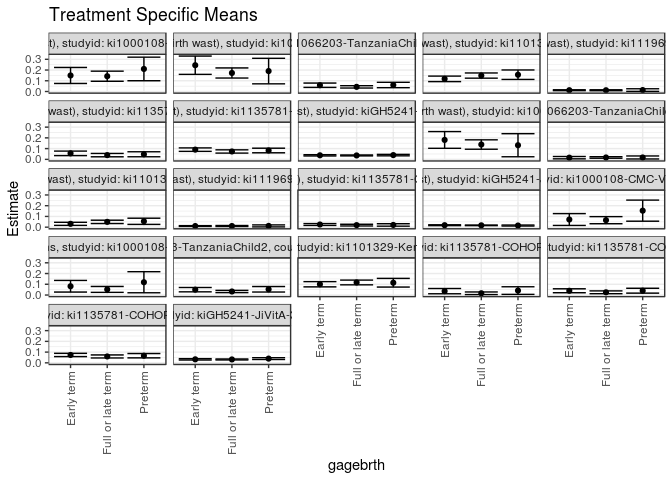

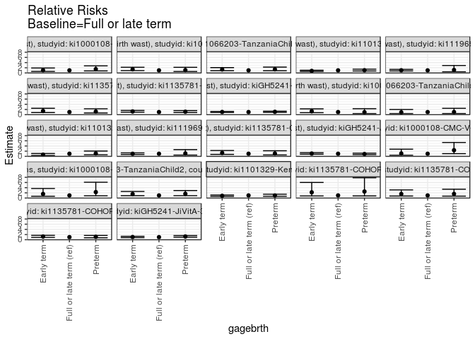

[figure not shown]

[figure not shown]

## Results Table

### Parameter: TSM

| agecat | studyid | country | intervention_level | baseline_level | estimate | ci_lower | ci_upper |
| --- | --- | --- | --- | --- | --- | --- | --- |
| 0-24 months (no birth wast) | ki1000108-CMC-V-BCS-2002 | INDIA | Full or late term | NA | 0.1424829 | 0.0954192 | 0.1895466 |
| 0-24 months (no birth wast) | ki1000108-CMC-V-BCS-2002 | INDIA | Preterm | NA | 0.2101747 | 0.1003398 | 0.3200095 |
| 0-24 months (no birth wast) | ki1000108-CMC-V-BCS-2002 | INDIA | Early term | NA | 0.1495037 | 0.0750230 | 0.2239844 |
| 0-24 months (no birth wast) | ki1000108-IRC | INDIA | Full or late term | NA | 0.1726908 | 0.1256823 | 0.2196992 |
| 0-24 months (no birth wast) | ki1000108-IRC | INDIA | Preterm | NA | 0.1904762 | 0.0715664 | 0.3093860 |
| 0-24 months (no birth wast) | ki1000108-IRC | INDIA | Early term | NA | 0.2448980 | 0.1596489 | 0.3301470 |
| 0-24 months (no birth wast) | ki1066203-TanzaniaChild2 | TANZANIA, UNITED REPUBLIC OF | Full or late term | NA | 0.0433502 | 0.0326037 | 0.0540966 |
| 0-24 months (no birth wast) | ki1066203-TanzaniaChild2 | TANZANIA, UNITED REPUBLIC OF | Preterm | NA | 0.0605616 | 0.0354479 | 0.0856753 |
| 0-24 months (no birth wast) | ki1066203-TanzaniaChild2 | TANZANIA, UNITED REPUBLIC OF | Early term | NA | 0.0584291 | 0.0382218 | 0.0786364 |
| 0-24 months (no birth wast) | ki1101329-Keneba | GAMBIA | Full or late term | NA | 0.1484537 | 0.1242770 | 0.1726305 |
| 0-24 months (no birth wast) | ki1101329-Keneba | GAMBIA | Preterm | NA | 0.1564154 | 0.1123340 | 0.2004968 |
| 0-24 months (no birth wast) | ki1101329-Keneba | GAMBIA | Early term | NA | 0.1180186 | 0.0923815 | 0.1436557 |
| 0-24 months (no birth wast) | ki1119695-PROBIT | BELARUS | Full or late term | NA | 0.0118316 | 0.0074560 | 0.0162072 |
| 0-24 months (no birth wast) | ki1119695-PROBIT | BELARUS | Preterm | NA | 0.0135364 | 0.0013326 | 0.0257401 |
| 0-24 months (no birth wast) | ki1119695-PROBIT | BELARUS | Early term | NA | 0.0122635 | 0.0085220 | 0.0160051 |
| 0-24 months (no birth wast) | ki1135781-COHORTS | INDIA | Full or late term | NA | 0.0394426 | 0.0236811 | 0.0552042 |
| 0-24 months (no birth wast) | ki1135781-COHORTS | INDIA | Preterm | NA | 0.0472570 | 0.0238807 | 0.0706333 |
| 0-24 months (no birth wast) | ki1135781-COHORTS | INDIA | Early term | NA | 0.0559027 | 0.0349272 | 0.0768783 |
| 0-24 months (no birth wast) | ki1135781-COHORTS | PHILIPPINES | Full or late term | NA | 0.0733796 | 0.0583726 | 0.0883867 |
| 0-24 months (no birth wast) | ki1135781-COHORTS | PHILIPPINES | Preterm | NA | 0.0824082 | 0.0609731 | 0.1038434 |
| 0-24 months (no birth wast) | ki1135781-COHORTS | PHILIPPINES | Early term | NA | 0.0905500 | 0.0743936 | 0.1067064 |
| 0-24 months (no birth wast) | kiGH5241-JiVitA-3 | BANGLADESH | Full or late term | NA | 0.0364205 | 0.0324000 | 0.0404410 |
| 0-24 months (no birth wast) | kiGH5241-JiVitA-3 | BANGLADESH | Preterm | NA | 0.0395768 | 0.0327809 | 0.0463727 |
| 0-24 months (no birth wast) | kiGH5241-JiVitA-3 | BANGLADESH | Early term | NA | 0.0376214 | 0.0317808 | 0.0434619 |
| 0-6 months (no birth wast) | ki1000108-IRC | INDIA | Full or late term | NA | 0.1380753 | 0.0942800 | 0.1818707 |
| 0-6 months (no birth wast) | ki1000108-IRC | INDIA | Preterm | NA | 0.1315789 | 0.0239570 | 0.2392009 |
| 0-6 months (no birth wast) | ki1000108-IRC | INDIA | Early term | NA | 0.1808511 | 0.1029377 | 0.2587645 |
| 0-6 months (no birth wast) | ki1066203-TanzaniaChild2 | TANZANIA, UNITED REPUBLIC OF | Full or late term | NA | 0.0173913 | 0.0104927 | 0.0242899 |
| 0-6 months (no birth wast) | ki1066203-TanzaniaChild2 | TANZANIA, UNITED REPUBLIC OF | Preterm | NA | 0.0174927 | 0.0036157 | 0.0313697 |
| 0-6 months (no birth wast) | ki1066203-TanzaniaChild2 | TANZANIA, UNITED REPUBLIC OF | Early term | NA | 0.0156556 | 0.0048899 | 0.0264213 |
| 0-6 months (no birth wast) | ki1101329-Keneba | GAMBIA | Full or late term | NA | 0.0494831 | 0.0339982 | 0.0649680 |
| 0-6 months (no birth wast) | ki1101329-Keneba | GAMBIA | Preterm | NA | 0.0547340 | 0.0259032 | 0.0835649 |
| 0-6 months (no birth wast) | ki1101329-Keneba | GAMBIA | Early term | NA | 0.0311643 | 0.0167039 | 0.0456247 |
| 0-6 months (no birth wast) | ki1119695-PROBIT | BELARUS | Full or late term | NA | 0.0108159 | 0.0062945 | 0.0153372 |
| 0-6 months (no birth wast) | ki1119695-PROBIT | BELARUS | Preterm | NA | 0.0120275 | 0.0028081 | 0.0212469 |
| 0-6 months (no birth wast) | ki1119695-PROBIT | BELARUS | Early term | NA | 0.0105694 | 0.0069148 | 0.0142241 |
| 0-6 months (no birth wast) | ki1135781-COHORTS | PHILIPPINES | Full or late term | NA | 0.0191706 | 0.0111796 | 0.0271615 |
| 0-6 months (no birth wast) | ki1135781-COHORTS | PHILIPPINES | Preterm | NA | 0.0208099 | 0.0095080 | 0.0321117 |
| 0-6 months (no birth wast) | ki1135781-COHORTS | PHILIPPINES | Early term | NA | 0.0249484 | 0.0161061 | 0.0337906 |
| 0-6 months (no birth wast) | kiGH5241-JiVitA-3 | BANGLADESH | Full or late term | NA | 0.0171290 | 0.0142191 | 0.0200389 |
| 0-6 months (no birth wast) | kiGH5241-JiVitA-3 | BANGLADESH | Preterm | NA | 0.0154102 | 0.0108636 | 0.0199567 |
| 0-6 months (no birth wast) | kiGH5241-JiVitA-3 | BANGLADESH | Early term | NA | 0.0184797 | 0.0144939 | 0.0224656 |
| 6-24 months | ki1000108-CMC-V-BCS-2002 | INDIA | Full or late term | NA | 0.0651163 | 0.0320891 | 0.0981435 |
| 6-24 months | ki1000108-CMC-V-BCS-2002 | INDIA | Preterm | NA | 0.1538462 | 0.0556411 | 0.2520512 |
| 6-24 months | ki1000108-CMC-V-BCS-2002 | INDIA | Early term | NA | 0.0714286 | 0.0162753 | 0.1265819 |
| 6-24 months | ki1000108-IRC | INDIA | Full or late term | NA | 0.0520000 | 0.0244424 | 0.0795576 |
| 6-24 months | ki1000108-IRC | INDIA | Preterm | NA | 0.1190476 | 0.0209818 | 0.2171134 |
| 6-24 months | ki1000108-IRC | INDIA | Early term | NA | 0.0816327 | 0.0273535 | 0.1359118 |
| 6-24 months | ki1066203-TanzaniaChild2 | TANZANIA, UNITED REPUBLIC OF | Full or late term | NA | 0.0327855 | 0.0225150 | 0.0430560 |
| 6-24 months | ki1066203-TanzaniaChild2 | TANZANIA, UNITED REPUBLIC OF | Preterm | NA | 0.0534694 | 0.0279344 | 0.0790043 |
| 6-24 months | ki1066203-TanzaniaChild2 | TANZANIA, UNITED REPUBLIC OF | Early term | NA | 0.0497407 | 0.0294280 | 0.0700535 |
| 6-24 months | ki1101329-Keneba | GAMBIA | Full or late term | NA | 0.1169662 | 0.0948422 | 0.1390902 |
| 6-24 months | ki1101329-Keneba | GAMBIA | Preterm | NA | 0.1143647 | 0.0740243 | 0.1547052 |
| 6-24 months | ki1101329-Keneba | GAMBIA | Early term | NA | 0.1003565 | 0.0759357 | 0.1247773 |
| 6-24 months | ki1135781-COHORTS | GUATEMALA | Full or late term | NA | 0.0163934 | 0.0043414 | 0.0284455 |
| 6-24 months | ki1135781-COHORTS | GUATEMALA | Preterm | NA | 0.0413223 | 0.0058355 | 0.0768091 |
| 6-24 months | ki1135781-COHORTS | GUATEMALA | Early term | NA | 0.0361991 | 0.0115570 | 0.0608412 |
| 6-24 months | ki1135781-COHORTS | INDIA | Full or late term | NA | 0.0252982 | 0.0122617 | 0.0383346 |
| 6-24 months | ki1135781-COHORTS | INDIA | Preterm | NA | 0.0401051 | 0.0175090 | 0.0627011 |
| 6-24 months | ki1135781-COHORTS | INDIA | Early term | NA | 0.0395348 | 0.0211825 | 0.0578871 |
| 6-24 months | ki1135781-COHORTS | PHILIPPINES | Full or late term | NA | 0.0594743 | 0.0453058 | 0.0736428 |
| 6-24 months | ki1135781-COHORTS | PHILIPPINES | Preterm | NA | 0.0665676 | 0.0463797 | 0.0867556 |
| 6-24 months | ki1135781-COHORTS | PHILIPPINES | Early term | NA | 0.0733699 | 0.0581002 | 0.0886397 |
| 6-24 months | kiGH5241-JiVitA-3 | BANGLADESH | Full or late term | NA | 0.0317078 | 0.0271908 | 0.0362248 |
| 6-24 months | kiGH5241-JiVitA-3 | BANGLADESH | Preterm | NA | 0.0394625 | 0.0310997 | 0.0478253 |
| 6-24 months | kiGH5241-JiVitA-3 | BANGLADESH | Early term | NA | 0.0328147 | 0.0265397 | 0.0390896 |

### Parameter: E(Y)

| agecat | studyid | country | intervention_level | baseline_level | estimate | ci_lower | ci_upper |
| --- | --- | --- | --- | --- | --- | --- | --- |
| 0-24 months (no birth wast) | ki1000108-CMC-V-BCS-2002 | INDIA | NA | NA | 0.1494253 | 0.1119149 | 0.1869357 |
| 0-24 months (no birth wast) | ki1000108-IRC | INDIA | NA | NA | 0.1928021 | 0.1535486 | 0.2320555 |
| 0-24 months (no birth wast) | ki1066203-TanzaniaChild2 | TANZANIA, UNITED REPUBLIC OF | NA | NA | 0.0495094 | 0.0405280 | 0.0584908 |
| 0-24 months (no birth wast) | ki1101329-Keneba | GAMBIA | NA | NA | 0.1389710 | 0.1224789 | 0.1554631 |
| 0-24 months (no birth wast) | ki1119695-PROBIT | BELARUS | NA | NA | 0.0120875 | 0.0084025 | 0.0157724 |
| 0-24 months (no birth wast) | ki1135781-COHORTS | INDIA | NA | NA | 0.0460967 | 0.0348859 | 0.0573074 |
| 0-24 months (no birth wast) | ki1135781-COHORTS | PHILIPPINES | NA | NA | 0.0821918 | 0.0723504 | 0.0920332 |
| 0-24 months (no birth wast) | kiGH5241-JiVitA-3 | BANGLADESH | NA | NA | 0.0374074 | 0.0343544 | 0.0404603 |
| 0-6 months (no birth wast) | ki1000108-IRC | INDIA | NA | NA | 0.1482480 | 0.1120405 | 0.1844555 |
| 0-6 months (no birth wast) | ki1066203-TanzaniaChild2 | TANZANIA, UNITED REPUBLIC OF | NA | NA | 0.0170098 | 0.0116466 | 0.0223731 |
| 0-6 months (no birth wast) | ki1101329-Keneba | GAMBIA | NA | NA | 0.0438144 | 0.0336280 | 0.0540009 |
| 0-6 months (no birth wast) | ki1119695-PROBIT | BELARUS | NA | NA | 0.0107462 | 0.0070475 | 0.0144449 |
| 0-6 months (no birth wast) | ki1135781-COHORTS | PHILIPPINES | NA | NA | 0.0218708 | 0.0166115 | 0.0271301 |
| 0-6 months (no birth wast) | kiGH5241-JiVitA-3 | BANGLADESH | NA | NA | 0.0171849 | 0.0150038 | 0.0193661 |
| 6-24 months | ki1000108-CMC-V-BCS-2002 | INDIA | NA | NA | 0.0797721 | 0.0513872 | 0.1081570 |
| 6-24 months | ki1000108-IRC | INDIA | NA | NA | 0.0666667 | 0.0418784 | 0.0914549 |
| 6-24 months | ki1066203-TanzaniaChild2 | TANZANIA, UNITED REPUBLIC OF | NA | NA | 0.0400633 | 0.0312360 | 0.0488905 |
| 6-24 months | ki1101329-Keneba | GAMBIA | NA | NA | 0.1107034 | 0.0954900 | 0.1259167 |
| 6-24 months | ki1135781-COHORTS | GUATEMALA | NA | NA | 0.0260078 | 0.0147515 | 0.0372641 |
| 6-24 months | ki1135781-COHORTS | INDIA | NA | NA | 0.0339111 | 0.0241689 | 0.0436532 |
| 6-24 months | ki1135781-COHORTS | PHILIPPINES | NA | NA | 0.0667384 | 0.0574713 | 0.0760056 |
| 6-24 months | kiGH5241-JiVitA-3 | BANGLADESH | NA | NA | 0.0335958 | 0.0302945 | 0.0368970 |

### Parameter: RR

| agecat | studyid | country | intervention_level | baseline_level | estimate | ci_lower | ci_upper |
| --- | --- | --- | --- | --- | --- | --- | --- |
| 0-24 months (no birth wast) | ki1000108-CMC-V-BCS-2002 | INDIA | Full or late term | Full or late term | 1.0000000 | 1.0000000 | 1.000000 |
| 0-24 months (no birth wast) | ki1000108-CMC-V-BCS-2002 | INDIA | Preterm | Full or late term | 1.4750867 | 0.7932657 | 2.742941 |
| 0-24 months (no birth wast) | ki1000108-CMC-V-BCS-2002 | INDIA | Early term | Full or late term | 1.0492746 | 0.5760787 | 1.911158 |
| 0-24 months (no birth wast) | ki1000108-IRC | INDIA | Full or late term | Full or late term | 1.0000000 | 1.0000000 | 1.000000 |
| 0-24 months (no birth wast) | ki1000108-IRC | INDIA | Preterm | Full or late term | 1.1029900 | 0.5582108 | 2.179440 |
| 0-24 months (no birth wast) | ki1000108-IRC | INDIA | Early term | Full or late term | 1.4181300 | 0.9115965 | 2.206122 |
| 0-24 months (no birth wast) | ki1066203-TanzaniaChild2 | TANZANIA, UNITED REPUBLIC OF | Full or late term | Full or late term | 1.0000000 | 1.0000000 | 1.000000 |
| 0-24 months (no birth wast) | ki1066203-TanzaniaChild2 | TANZANIA, UNITED REPUBLIC OF | Preterm | Full or late term | 1.3970330 | 0.8617669 | 2.264767 |
| 0-24 months (no birth wast) | ki1066203-TanzaniaChild2 | TANZANIA, UNITED REPUBLIC OF | Early term | Full or late term | 1.3478405 | 0.8806794 | 2.062810 |
| 0-24 months (no birth wast) | ki1101329-Keneba | GAMBIA | Full or late term | Full or late term | 1.0000000 | 1.0000000 | 1.000000 |
| 0-24 months (no birth wast) | ki1101329-Keneba | GAMBIA | Preterm | Full or late term | 1.0536303 | 0.7610189 | 1.458751 |
| 0-24 months (no birth wast) | ki1101329-Keneba | GAMBIA | Early term | Full or late term | 0.7949856 | 0.6065092 | 1.042032 |
| 0-24 months (no birth wast) | ki1119695-PROBIT | BELARUS | Full or late term | Full or late term | 1.0000000 | 1.0000000 | 1.000000 |
| 0-24 months (no birth wast) | ki1119695-PROBIT | BELARUS | Preterm | Full or late term | 1.1440894 | 0.4554164 | 2.874162 |
| 0-24 months (no birth wast) | ki1119695-PROBIT | BELARUS | Early term | Full or late term | 1.0365092 | 0.7781711 | 1.380611 |
| 0-24 months (no birth wast) | ki1135781-COHORTS | INDIA | Full or late term | Full or late term | 1.0000000 | 1.0000000 | 1.000000 |
| 0-24 months (no birth wast) | ki1135781-COHORTS | INDIA | Preterm | Full or late term | 1.1981192 | 0.6344665 | 2.262515 |
| 0-24 months (no birth wast) | ki1135781-COHORTS | INDIA | Early term | Full or late term | 1.4173176 | 0.8193331 | 2.451737 |
| 0-24 months (no birth wast) | ki1135781-COHORTS | PHILIPPINES | Full or late term | Full or late term | 1.0000000 | 1.0000000 | 1.000000 |
| 0-24 months (no birth wast) | ki1135781-COHORTS | PHILIPPINES | Preterm | Full or late term | 1.1230394 | 0.8067423 | 1.563346 |
| 0-24 months (no birth wast) | ki1135781-COHORTS | PHILIPPINES | Early term | Full or late term | 1.2339935 | 0.9408851 | 1.618412 |
| 0-24 months (no birth wast) | kiGH5241-JiVitA-3 | BANGLADESH | Full or late term | Full or late term | 1.0000000 | 1.0000000 | 1.000000 |
| 0-24 months (no birth wast) | kiGH5241-JiVitA-3 | BANGLADESH | Preterm | Full or late term | 1.0866629 | 0.8923904 | 1.323228 |
| 0-24 months (no birth wast) | kiGH5241-JiVitA-3 | BANGLADESH | Early term | Full or late term | 1.0329717 | 0.8553054 | 1.247543 |
| 0-6 months (no birth wast) | ki1000108-IRC | INDIA | Full or late term | Full or late term | 1.0000000 | 1.0000000 | 1.000000 |
| 0-6 months (no birth wast) | ki1000108-IRC | INDIA | Preterm | Full or late term | 0.9529506 | 0.3963465 | 2.291214 |
| 0-6 months (no birth wast) | ki1000108-IRC | INDIA | Early term | Full or late term | 1.3098001 | 0.7671220 | 2.236380 |
| 0-6 months (no birth wast) | ki1066203-TanzaniaChild2 | TANZANIA, UNITED REPUBLIC OF | Full or late term | Full or late term | 1.0000000 | 1.0000000 | 1.000000 |
| 0-6 months (no birth wast) | ki1066203-TanzaniaChild2 | TANZANIA, UNITED REPUBLIC OF | Preterm | Full or late term | 1.0058309 | 0.4143137 | 2.441859 |
| 0-6 months (no birth wast) | ki1066203-TanzaniaChild2 | TANZANIA, UNITED REPUBLIC OF | Early term | Full or late term | 0.9001957 | 0.4069725 | 1.991172 |
| 0-6 months (no birth wast) | ki1101329-Keneba | GAMBIA | Full or late term | Full or late term | 1.0000000 | 1.0000000 | 1.000000 |
| 0-6 months (no birth wast) | ki1101329-Keneba | GAMBIA | Preterm | Full or late term | 1.1061152 | 0.5993917 | 2.041221 |
| 0-6 months (no birth wast) | ki1101329-Keneba | GAMBIA | Early term | Full or late term | 0.6297976 | 0.3600262 | 1.101712 |
| 0-6 months (no birth wast) | ki1119695-PROBIT | BELARUS | Full or late term | Full or late term | 1.0000000 | 1.0000000 | 1.000000 |
| 0-6 months (no birth wast) | ki1119695-PROBIT | BELARUS | Preterm | Full or late term | 1.1120200 | 0.4780743 | 2.586603 |
| 0-6 months (no birth wast) | ki1119695-PROBIT | BELARUS | Early term | Full or late term | 0.9772125 | 0.7081553 | 1.348496 |
| 0-6 months (no birth wast) | ki1135781-COHORTS | PHILIPPINES | Full or late term | Full or late term | 1.0000000 | 1.0000000 | 1.000000 |
| 0-6 months (no birth wast) | ki1135781-COHORTS | PHILIPPINES | Preterm | Full or late term | 1.0855100 | 0.5473286 | 2.152879 |
| 0-6 months (no birth wast) | ki1135781-COHORTS | PHILIPPINES | Early term | Full or late term | 1.3013894 | 0.7529359 | 2.249347 |
| 0-6 months (no birth wast) | kiGH5241-JiVitA-3 | BANGLADESH | Full or late term | Full or late term | 1.0000000 | 1.0000000 | 1.000000 |
| 0-6 months (no birth wast) | kiGH5241-JiVitA-3 | BANGLADESH | Preterm | Full or late term | 0.8996540 | 0.6538199 | 1.237921 |
| 0-6 months (no birth wast) | kiGH5241-JiVitA-3 | BANGLADESH | Early term | Full or late term | 1.0788557 | 0.8238264 | 1.412834 |
| 6-24 months | ki1000108-CMC-V-BCS-2002 | INDIA | Full or late term | Full or late term | 1.0000000 | 1.0000000 | 1.000000 |
| 6-24 months | ki1000108-CMC-V-BCS-2002 | INDIA | Preterm | Full or late term | 2.3626374 | 1.0454758 | 5.339249 |
| 6-24 months | ki1000108-CMC-V-BCS-2002 | INDIA | Early term | Full or late term | 1.0969388 | 0.4354790 | 2.763106 |
| 6-24 months | ki1000108-IRC | INDIA | Full or late term | Full or late term | 1.0000000 | 1.0000000 | 1.000000 |
| 6-24 months | ki1000108-IRC | INDIA | Preterm | Full or late term | 2.2893773 | 0.8596588 | 6.096894 |
| 6-24 months | ki1000108-IRC | INDIA | Early term | Full or late term | 1.5698587 | 0.6707962 | 3.673927 |
| 6-24 months | ki1066203-TanzaniaChild2 | TANZANIA, UNITED REPUBLIC OF | Full or late term | Full or late term | 1.0000000 | 1.0000000 | 1.000000 |
| 6-24 months | ki1066203-TanzaniaChild2 | TANZANIA, UNITED REPUBLIC OF | Preterm | Full or late term | 1.6308847 | 0.9212366 | 2.887190 |
| 6-24 months | ki1066203-TanzaniaChild2 | TANZANIA, UNITED REPUBLIC OF | Early term | Full or late term | 1.5171565 | 0.9066210 | 2.538838 |
| 6-24 months | ki1101329-Keneba | GAMBIA | Full or late term | Full or late term | 1.0000000 | 1.0000000 | 1.000000 |
| 6-24 months | ki1101329-Keneba | GAMBIA | Preterm | Full or late term | 0.9777587 | 0.6552622 | 1.458976 |
| 6-24 months | ki1101329-Keneba | GAMBIA | Early term | Full or late term | 0.8579956 | 0.6306208 | 1.167352 |
| 6-24 months | ki1135781-COHORTS | GUATEMALA | Full or late term | Full or late term | 1.0000000 | 1.0000000 | 1.000000 |
| 6-24 months | ki1135781-COHORTS | GUATEMALA | Preterm | Full or late term | 2.5206609 | 0.8138650 | 7.806862 |
| 6-24 months | ki1135781-COHORTS | GUATEMALA | Early term | Full or late term | 2.2081446 | 0.8107545 | 6.014031 |
| 6-24 months | ki1135781-COHORTS | INDIA | Full or late term | Full or late term | 1.0000000 | 1.0000000 | 1.000000 |
| 6-24 months | ki1135781-COHORTS | INDIA | Preterm | Full or late term | 1.5852963 | 0.7393065 | 3.399354 |
| 6-24 months | ki1135781-COHORTS | INDIA | Early term | Full or late term | 1.5627538 | 0.7808763 | 3.127511 |
| 6-24 months | ki1135781-COHORTS | PHILIPPINES | Full or late term | Full or late term | 1.0000000 | 1.0000000 | 1.000000 |
| 6-24 months | ki1135781-COHORTS | PHILIPPINES | Preterm | Full or late term | 1.1192672 | 0.7613236 | 1.645501 |
| 6-24 months | ki1135781-COHORTS | PHILIPPINES | Early term | Full or late term | 1.2336407 | 0.8994974 | 1.691911 |
| 6-24 months | kiGH5241-JiVitA-3 | BANGLADESH | Full or late term | Full or late term | 1.0000000 | 1.0000000 | 1.000000 |
| 6-24 months | kiGH5241-JiVitA-3 | BANGLADESH | Preterm | Full or late term | 1.2445676 | 0.9638863 | 1.606983 |
| 6-24 months | kiGH5241-JiVitA-3 | BANGLADESH | Early term | Full or late term | 1.0349077 | 0.8113514 | 1.320062 |

### Parameter: PAR

| agecat | studyid | country | intervention_level | baseline_level | estimate | ci_lower | ci_upper |
| --- | --- | --- | --- | --- | --- | --- | --- |
| 0-24 months (no birth wast) | ki1000108-CMC-V-BCS-2002 | INDIA | Full or late term | NA | 0.0069424 | -0.0237925 | 0.0376772 |
| 0-24 months (no birth wast) | ki1000108-IRC | INDIA | Full or late term | NA | 0.0201113 | -0.0102472 | 0.0504698 |
| 0-24 months (no birth wast) | ki1066203-TanzaniaChild2 | TANZANIA, UNITED REPUBLIC OF | Full or late term | NA | 0.0061592 | -0.0011787 | 0.0134971 |
| 0-24 months (no birth wast) | ki1101329-Keneba | GAMBIA | Full or late term | NA | -0.0094827 | -0.0260464 | 0.0070809 |
| 0-24 months (no birth wast) | ki1119695-PROBIT | BELARUS | Full or late term | NA | 0.0002559 | -0.0014408 | 0.0019526 |
| 0-24 months (no birth wast) | ki1135781-COHORTS | INDIA | Full or late term | NA | 0.0066540 | -0.0059186 | 0.0192267 |
| 0-24 months (no birth wast) | ki1135781-COHORTS | PHILIPPINES | Full or late term | NA | 0.0088121 | -0.0033194 | 0.0209437 |
| 0-24 months (no birth wast) | kiGH5241-JiVitA-3 | BANGLADESH | Full or late term | NA | 0.0009869 | -0.0018153 | 0.0037890 |
| 0-6 months (no birth wast) | ki1000108-IRC | INDIA | Full or late term | NA | 0.0101727 | -0.0173555 | 0.0377009 |
| 0-6 months (no birth wast) | ki1066203-TanzaniaChild2 | TANZANIA, UNITED REPUBLIC OF | Full or late term | NA | -0.0003815 | -0.0045718 | 0.0038089 |
| 0-6 months (no birth wast) | ki1101329-Keneba | GAMBIA | Full or late term | NA | -0.0056687 | -0.0160816 | 0.0047443 |
| 0-6 months (no birth wast) | ki1119695-PROBIT | BELARUS | Full or late term | NA | -0.0000697 | -0.0018367 | 0.0016974 |
| 0-6 months (no birth wast) | ki1135781-COHORTS | PHILIPPINES | Full or late term | NA | 0.0027002 | -0.0038397 | 0.0092401 |
| 0-6 months (no birth wast) | kiGH5241-JiVitA-3 | BANGLADESH | Full or late term | NA | 0.0000559 | -0.0018520 | 0.0019638 |
| 6-24 months | ki1000108-CMC-V-BCS-2002 | INDIA | Full or late term | NA | 0.0146558 | -0.0090126 | 0.0383242 |
| 6-24 months | ki1000108-IRC | INDIA | Full or late term | NA | 0.0146667 | -0.0053399 | 0.0346732 |
| 6-24 months | ki1066203-TanzaniaChild2 | TANZANIA, UNITED REPUBLIC OF | Full or late term | NA | 0.0072778 | -0.0001241 | 0.0146796 |
| 6-24 months | ki1101329-Keneba | GAMBIA | Full or late term | NA | -0.0062628 | -0.0215161 | 0.0089904 |
| 6-24 months | ki1135781-COHORTS | GUATEMALA | Full or late term | NA | 0.0096144 | -0.0009047 | 0.0201334 |
| 6-24 months | ki1135781-COHORTS | INDIA | Full or late term | NA | 0.0086129 | -0.0022347 | 0.0194605 |
| 6-24 months | ki1135781-COHORTS | PHILIPPINES | Full or late term | NA | 0.0072641 | -0.0041536 | 0.0186819 |
| 6-24 months | kiGH5241-JiVitA-3 | BANGLADESH | Full or late term | NA | 0.0018880 | -0.0014089 | 0.0051848 |

### Parameter: PAF

| agecat | studyid | country | intervention_level | baseline_level | estimate | ci_lower | ci_upper |
| --- | --- | --- | --- | --- | --- | --- | --- |
| 0-24 months (no birth wast) | ki1000108-CMC-V-BCS-2002 | INDIA | Full or late term | NA | 0.0464605 | -0.1826479 | 0.2311848 |
| 0-24 months (no birth wast) | ki1000108-IRC | INDIA | Full or late term | NA | 0.1043106 | -0.0668583 | 0.2480168 |
| 0-24 months (no birth wast) | ki1066203-TanzaniaChild2 | TANZANIA, UNITED REPUBLIC OF | Full or late term | NA | 0.1244048 | -0.0352592 | 0.2594444 |
| 0-24 months (no birth wast) | ki1101329-Keneba | GAMBIA | Full or late term | NA | -0.0682353 | -0.1940010 | 0.0442834 |
| 0-24 months (no birth wast) | ki1119695-PROBIT | BELARUS | Full or late term | NA | 0.0211692 | -0.1315283 | 0.1532605 |
| 0-24 months (no birth wast) | ki1135781-COHORTS | INDIA | Full or late term | NA | 0.1443496 | -0.1739258 | 0.3763340 |
| 0-24 months (no birth wast) | ki1135781-COHORTS | PHILIPPINES | Full or late term | NA | 0.1072143 | -0.0527526 | 0.2428741 |
| 0-24 months (no birth wast) | kiGH5241-JiVitA-3 | BANGLADESH | Full or late term | NA | 0.0263815 | -0.0513803 | 0.0983919 |
| 0-6 months (no birth wast) | ki1000108-IRC | INDIA | Full or late term | NA | 0.0686192 | -0.1362511 | 0.2365507 |
| 0-6 months (no birth wast) | ki1066203-TanzaniaChild2 | TANZANIA, UNITED REPUBLIC OF | Full or late term | NA | -0.0224256 | -0.3008630 | 0.1964149 |
| 0-6 months (no birth wast) | ki1101329-Keneba | GAMBIA | Full or late term | NA | -0.1293791 | -0.3914086 | 0.0833050 |
| 0-6 months (no birth wast) | ki1119695-PROBIT | BELARUS | Full or late term | NA | -0.0064824 | -0.1843989 | 0.1447080 |
| 0-6 months (no birth wast) | ki1135781-COHORTS | PHILIPPINES | Full or late term | NA | 0.1234620 | -0.2309773 | 0.3758465 |
| 0-6 months (no birth wast) | kiGH5241-JiVitA-3 | BANGLADESH | Full or late term | NA | 0.0032542 | -0.1141917 | 0.1083202 |
| 6-24 months | ki1000108-CMC-V-BCS-2002 | INDIA | Full or late term | NA | 0.1837209 | -0.1651221 | 0.4281187 |
| 6-24 months | ki1000108-IRC | INDIA | Full or late term | NA | 0.2200000 | -0.1312945 | 0.4622090 |
| 6-24 months | ki1066203-TanzaniaChild2 | TANZANIA, UNITED REPUBLIC OF | Full or late term | NA | 0.1816567 | -0.0205560 | 0.3438031 |
| 6-24 months | ki1101329-Keneba | GAMBIA | Full or late term | NA | -0.0565732 | -0.2035119 | 0.0724255 |
| 6-24 months | ki1135781-COHORTS | GUATEMALA | Full or late term | NA | 0.3696721 | -0.1384210 | 0.6509962 |
| 6-24 months | ki1135781-COHORTS | INDIA | Full or late term | NA | 0.2539856 | -0.1355513 | 0.5098966 |
| 6-24 months | ki1135781-COHORTS | PHILIPPINES | Full or late term | NA | 0.1088446 | -0.0792301 | 0.2641440 |
| 6-24 months | kiGH5241-JiVitA-3 | BANGLADESH | Full or late term | NA | 0.0561961 | -0.0470087 | 0.1492279 |